# Procesamiento y análisis de los datos

Integrantes: Catalina Opazo y Arturo Zapata

El presente documento busta dar un sustento aplicado a las restricciones y supuestos realizados en el informe. Para ello, procederemos a analizar los datos, sus características y dimensiones máximas. Se establecerán aquellas palabras que no aportan en nuestro análisis y se propondrá una bolsa de palabras representativa con los mensajes de la muestra.

### Librerías a utilizar:

```python
import pandas as pd
import matplotlib.pyplot as plt
import re
import string
import math as m

import nltk
#nltk.download('stopwords')
#nltk.download('punkt')
from nltk import word_tokenize, pos_tag
from nltk.corpus import PlaintextCorpusReader, stopwords

from sklearn.feature_extraction.text import CountVectorizer
```

## Primer análisis: Los datos

En esta sección se dará a conocer el sustento para la información presentada en la sección "ANÁLISIS DESCRIPTIVO DE LOS DATOS".

```python
r_inicial = pd.read_csv('dataset-proyecto.csv',sep=',')
```

```python
r_inicial
```

|  | TweetId | TweetDate | TweetText | UserId |
| --- | --- | --- | --- | --- |
| 0 | 126415614616154112 | Tue Oct 18 21:53:25 +0000 2011 | Now all @Apple has to do is get swype on the i... | 464158801 |
| 1 | 126404574230740992 | Tue Oct 18 21:09:33 +0000 2011 | @Apple will be adding more carrier support to ... | 439392988 |
| 2 | 126402758403305474 | Tue Oct 18 21:02:20 +0000 2011 | Hilarious @youtube video - guy does a duet wit... | 422248520 |
| 3 | 126397179614068736 | Tue Oct 18 20:40:10 +0000 2011 | @RIM you made it too easy for me to switch to ... | 357545630 |
| 4 | 126395626979196928 | Tue Oct 18 20:34:00 +0000 2011 | I just realized that the reason I got into twi... | 476185067 |
| ... | ... | ... | ... | ... |
| 5108 | 126855687060987904 | Thu Oct 20 03:02:07 +0000 2011 | me re copè con #twitter | 389663163 |
| 5109 | 126855171702661120 | Thu Oct 20 03:00:04 +0000 2011 | Buenas noches genteeee :) #twitter los quieroo... | 439392988 |
| 5110 | 126854999442587648 | Thu Oct 20 02:59:23 +0000 2011 | #twitter tiene la mala costumbre de ponerce bn... | 314552166 |
| 5111 | 126854818101858304 | Thu Oct 20 02:58:40 +0000 2011 | Oi @flaviasansi. Muito bem vinda ao meu #Twitt... | 439654060 |
| 5112 | 126854423317188608 | Thu Oct 20 02:57:06 +0000 2011 | Eles arrastaram os barcos para a praia, deixar... | 475765632 |

5113 rows × 4 columns

En la lectura de los datos podemos ver la muestra de Twitter con sus cuatro características mencionadas en el informe. Una primera pregunta es si el id del mensaje es único para cada línea. Mediante un conteo podemos ver que estas sí son únicas y pueden ser establecidas como primera restricción para el llenado de la estructura de datos.

```python
r_inicial["TweetId"].value_counts()
```

```
126415614616154112    1
126762153012236288    1
126759818718482432    1
126759986780057600    1
126760617800515584    1
                     ..
126505392191705088    1
126505412068511745    1
126505424823402496    1
126505469601775616    1
126854423317188608    1
Name: TweetId, Length: 5113, dtype: int64
```

Se analiza el número de mensajes que un usuario en la muestra a enviado y se identifican 100 usuarios distintos en esta.

```python
r_inicial["UserId"].value_counts()
```

```
336253549    70
509888321    68
283374516    66
439392988    66
469434364    65
             ..
286281842    36
344271212    36
334590243    34
407240055    34
294610621    25
Name: UserId, Length: 100, dtype: int64
```

```python
r_inicial["UserId"].nunique()
```

```
100
```

```python
r_inicial["TweetDate"].value_counts()
```

```
Wed Oct 19 03:34:33 +0000 2011    9
Wed Oct 19 03:13:22 +0000 2011    9
Thu Oct 20 04:28:59 +0000 2011    5
Thu Oct 20 03:30:04 +0000 2011    5
Wed Oct 19 21:20:06 +0000 2011    5
                                 ..
Wed Oct 19 04:14:03 +0000 2011    1
Wed Oct 19 04:14:28 +0000 2011    1
Wed Oct 19 04:14:45 +0000 2011    1
Wed Oct 19 04:14:56 +0000 2011    1
Thu Oct 20 02:57:06 +0000 2011    1
Name: TweetDate, Length: 4803, dtype: int64
```

```python
r_inicial["TweetDate"].max()
```

```
'Wed Oct 19 23:57:30 +0000 2011'
```

```python
r_inicial["TweetDate"].min()
```

```
'Mon Oct 17 00:00:13 +0000 2011'
```

```python
r_inicial["TweetDate"].nunique()
```

```
4803
```

Se presenta el número de dígitos presentes en cada id y se identifican para su posterior análisis en la programación de la estructura.

```python
print('Ejemplo id de tweet:')
print(r_inicial["TweetId"].max())
print('Ejemplo id de usuario:')
print(r_inicial["UserId"].max())
```

```
Ejemplo id de tweet:
126883777938067457
Ejemplo id de usuario:
527271492
```

De manera similar, se realiza un análisis de los mensajes y fechas para determinar el largo necesario para este dato.

```python
print('Largo mínimo de un mensaje:')
print(r_inicial["TweetText"].apply(len).min())
print('Largo máximo de un mensaje:')
print(r_inicial["TweetText"].apply(len).max())
```

```
Largo mínimo de un mensaje:
8
Largo máximo de un mensaje:
160
```

```python
print('Largo mínimo de una fecha:')
print(r_inicial["TweetDate"].apply(len).min())
print('Largo máximo de una fecha:')
print(r_inicial["TweetDate"].apply(len).max())
```

```
Largo mínimo de una fecha:
30
Largo máximo de una fecha:
30
```

## Segunda parte: Bolsa de palabras

Otro aspecto a analizar es el número de palabras distintas que podemos encontrar. La recolección e identificación de estas palabras se denomina bolsa de palabras. En Python esto puede ser realizado mediante el tokenizado y almacenamiento de todas las cadenas de caracteres presentes en nuesta muestra en una matriz de tamaño N por M. El valor N representa el número de líneas que son analizadas y M el número de palabras distintas presentes en las N líneas.

```python
vec = CountVectorizer()
X = vec.fit_transform(r_inicial['TweetText'])
dtm = pd.DataFrame(X.toarray(), columns=vec.get_feature_names())
```

```python
dtm
```

|  | 00 | 000 | 001inthisworld | 00ohfly6 | 00pm | 01 | 020 | 02dyonxz | 03ihbogj | 0400ynqy | ... | 追悼ジョブズ氏 | 透過 | 配合 | 銀座 | 閉鎖じゃなくて | 音声認識やカメラの機能も向上させた戦略モデル | 顔認識ロック解除失敗してる | ６５型の有機ｅｌ画面を採用 | ｏｓ | ｺｺ |
| --- | --- | --- | --- | --- | --- | --- | --- | --- | --- | --- | --- | --- | --- | --- | --- | --- | --- | --- | --- | --- | --- |
| 0 | 0 | 0 | 0 | 0 | 0 | 0 | 0 | 0 | 0 | 0 | ... | 0 | 0 | 0 | 0 | 0 | 0 | 0 | 0 | 0 | 0 |
| 1 | 0 | 0 | 0 | 0 | 0 | 0 | 0 | 0 | 0 | 0 | ... | 0 | 0 | 0 | 0 | 0 | 0 | 0 | 0 | 0 | 0 |
| 2 | 0 | 0 | 0 | 0 | 0 | 0 | 0 | 0 | 0 | 0 | ... | 0 | 0 | 0 | 0 | 0 | 0 | 0 | 0 | 0 | 0 |
| 3 | 0 | 0 | 0 | 0 | 0 | 0 | 0 | 0 | 0 | 0 | ... | 0 | 0 | 0 | 0 | 0 | 0 | 0 | 0 | 0 | 0 |
| 4 | 0 | 0 | 0 | 0 | 0 | 0 | 0 | 0 | 0 | 0 | ... | 0 | 0 | 0 | 0 | 0 | 0 | 0 | 0 | 0 | 0 |
| ... | ... | ... | ... | ... | ... | ... | ... | ... | ... | ... | ... | ... | ... | ... | ... | ... | ... | ... | ... | ... | ... |
| 5108 | 0 | 0 | 0 | 0 | 0 | 0 | 0 | 0 | 0 | 0 | ... | 0 | 0 | 0 | 0 | 0 | 0 | 0 | 0 | 0 | 0 |
| 5109 | 0 | 0 | 0 | 0 | 0 | 0 | 0 | 0 | 0 | 0 | ... | 0 | 0 | 0 | 0 | 0 | 0 | 0 | 0 | 0 | 0 |
| 5110 | 0 | 0 | 0 | 0 | 0 | 0 | 0 | 0 | 0 | 0 | ... | 0 | 0 | 0 | 0 | 0 | 0 | 0 | 0 | 0 | 0 |
| 5111 | 0 | 0 | 0 | 0 | 0 | 0 | 0 | 0 | 0 | 0 | ... | 0 | 0 | 0 | 0 | 0 | 0 | 0 | 0 | 0 | 0 |
| 5112 | 0 | 0 | 0 | 0 | 0 | 0 | 0 | 0 | 0 | 0 | ... | 0 | 0 | 0 | 0 | 0 | 0 | 0 | 0 | 0 | 0 |

5113 rows × 15493 columns

```python
dtm.shape
```

```
(5113, 15493)
```

Con lo anterior notamos que existen 15493 cadenas de caracteres distintas. Sin embargo, en la siguiente gráfica de frecuencias, notamos que existen palabras con un bajo valor para nuestro análisis.

```python
v_i = 300
freq = dtm.sum(axis = 0)
```

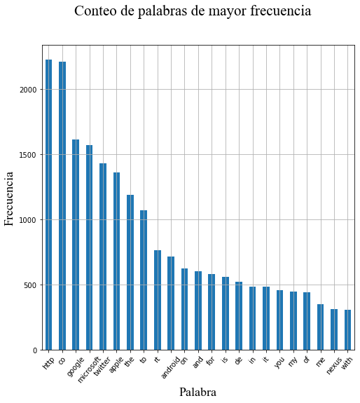

```python
csfont = {'fontname':'Times New Roman'}
plt.figure(figsize=(8,8))
freq[freq>v_i].sort_values(ascending=False).plot.bar().grid()
plt.xticks(rotation=50)
plt.xlabel("Palabra", fontsize=18,**csfont)
plt.ylabel("Frecuencia", fontsize=18,**csfont)
plt.suptitle('Conteo de palabras de mayor frecuencia', fontsize=21,**csfont)
plt.show()
```

De manera similar al análisis realizado en el informe, notamos palabras con un bajo valor en su significado y poseen un valor en el sentido del idioma. Con lo anterior nos referimos a conectores y palabras que buscar dar a entender una idea pero sin valor por sí misma.

## Tercera parte: Procesamiento de las palabras

```python
r_procesar=r_inicial
r_procesar
```

|  | TweetId | TweetDate | TweetText | UserId |
| --- | --- | --- | --- | --- |
| 0 | 126415614616154112 | Tue Oct 18 21:53:25 +0000 2011 | Now all @Apple has to do is get swype on the i... | 464158801 |
| 1 | 126404574230740992 | Tue Oct 18 21:09:33 +0000 2011 | @Apple will be adding more carrier support to ... | 439392988 |
| 2 | 126402758403305474 | Tue Oct 18 21:02:20 +0000 2011 | Hilarious @youtube video - guy does a duet wit... | 422248520 |
| 3 | 126397179614068736 | Tue Oct 18 20:40:10 +0000 2011 | @RIM you made it too easy for me to switch to ... | 357545630 |
| 4 | 126395626979196928 | Tue Oct 18 20:34:00 +0000 2011 | I just realized that the reason I got into twi... | 476185067 |
| ... | ... | ... | ... | ... |
| 5108 | 126855687060987904 | Thu Oct 20 03:02:07 +0000 2011 | me re copè con #twitter | 389663163 |
| 5109 | 126855171702661120 | Thu Oct 20 03:00:04 +0000 2011 | Buenas noches genteeee :) #twitter los quieroo... | 439392988 |
| 5110 | 126854999442587648 | Thu Oct 20 02:59:23 +0000 2011 | #twitter tiene la mala costumbre de ponerce bn... | 314552166 |
| 5111 | 126854818101858304 | Thu Oct 20 02:58:40 +0000 2011 | Oi @flaviasansi. Muito bem vinda ao meu #Twitt... | 439654060 |
| 5112 | 126854423317188608 | Thu Oct 20 02:57:06 +0000 2011 | Eles arrastaram os barcos para a praia, deixar... | 475765632 |

5113 rows × 4 columns

Como primer criterio de limpieza, es necesario extraer todo tipo de signo de puntuación. Lo anterior es debido a que no aporta a nivel de palabra la puntuación que acompañe a las palabras. Además, se pasará todas las palabras a minúscula asumiendo que su significado no cambia según su forma de escribir.

```python
def clean_text_round1(text):
    text = text.lower()
    text = re.sub('\[.*?¿\]\%"“”', ' ', text)
    text = re.sub('[%s]' % re.escape(string.punctuation), ' ', text)
    text = re.sub('\w*\d\w*', '', text)
    return text

round1 = lambda x: clean_text_round1(x)
```

```python
r_procesar['TweetText'] = pd.DataFrame(r_procesar.TweetText.apply(round1))
r_procesar
```

|  | TweetId | TweetDate | TweetText | UserId |
| --- | --- | --- | --- | --- |
| 0 | 126415614616154112 | Tue Oct 18 21:53:25 +0000 2011 | now all apple has to do is get swype on the i... | 464158801 |
| 1 | 126404574230740992 | Tue Oct 18 21:09:33 +0000 2011 | apple will be adding more carrier support to ... | 439392988 |
| 2 | 126402758403305474 | Tue Oct 18 21:02:20 +0000 2011 | hilarious youtube video guy does a duet wit... | 422248520 |
| 3 | 126397179614068736 | Tue Oct 18 20:40:10 +0000 2011 | rim you made it too easy for me to switch to ... | 357545630 |
| 4 | 126395626979196928 | Tue Oct 18 20:34:00 +0000 2011 | i just realized that the reason i got into twi... | 476185067 |
| ... | ... | ... | ... | ... |
| 5108 | 126855687060987904 | Thu Oct 20 03:02:07 +0000 2011 | me re copè con twitter | 389663163 |
| 5109 | 126855171702661120 | Thu Oct 20 03:00:04 +0000 2011 | buenas noches genteeee twitter los quieroo... | 439392988 |
| 5110 | 126854999442587648 | Thu Oct 20 02:59:23 +0000 2011 | twitter tiene la mala costumbre de ponerce bn... | 314552166 |
| 5111 | 126854818101858304 | Thu Oct 20 02:58:40 +0000 2011 | oi flaviasansi muito bem vinda ao meu twitt... | 439654060 |
| 5112 | 126854423317188608 | Thu Oct 20 02:57:06 +0000 2011 | eles arrastaram os barcos para a praia deixar... | 475765632 |

5113 rows × 4 columns

Otro criterio a destacar son las StopWord. Como estas poseen una importancia a nivel de oración, no nos aporta en el análisis ya que estas se ven presentes en gran cantidad pero no aportan al significado de la muestra. Es por ello que, mediente librerías extraídas de trabajos realizados en esta línea, se eliminan estas palabras para alguno de los idiomas identificados en la muestra.

```python
stop_words_sp = set(stopwords.words('spanish'))
stop_words_en = set(stopwords.words('english'))
stop_words_chi = set(stopwords.words('chinese'))
stop_words_por = set(stopwords.words('portuguese'))
r_procesar['TweetText'] = r_procesar['TweetText'].apply(lambda x: ' '.join([i for i in word_tokenize(x) if not i in stop_words_sp]))
r_procesar['TweetText'] = r_procesar['TweetText'].apply(lambda x: ' '.join([i for i in word_tokenize(x) if not i in stop_words_en]))
r_procesar['TweetText'] = r_procesar['TweetText'].apply(lambda x: ' '.join([i for i in word_tokenize(x) if not i in stop_words_chi]))
r_procesar['TweetText'] = r_procesar['TweetText'].apply(lambda x: ' '.join([i for i in word_tokenize(x) if not i in stop_words_por]))
```

```python
r_procesar
```

|  | TweetId | TweetDate | TweetText | UserId |
| --- | --- | --- | --- | --- |
| 0 | 126415614616154112 | Tue Oct 18 21:53:25 +0000 2011 | apple get swype iphone crack iphone | 464158801 |
| 1 | 126404574230740992 | Tue Oct 18 21:09:33 +0000 2011 | apple adding carrier support iphone announced | 439392988 |
| 2 | 126402758403305474 | Tue Oct 18 21:02:20 +0000 2011 | hilarious youtube video guy duet apple siri pr... | 422248520 |
| 3 | 126397179614068736 | Tue Oct 18 20:40:10 +0000 2011 | rim made easy switch apple iphone see | 357545630 |
| 4 | 126395626979196928 | Tue Oct 18 20:34:00 +0000 2011 | realized reason got twitter thanks apple | 476185067 |
| ... | ... | ... | ... | ... |
| 5108 | 126855687060987904 | Thu Oct 20 03:02:07 +0000 2011 | copè twitter | 389663163 |
| 5109 | 126855171702661120 | Thu Oct 20 03:00:04 +0000 2011 | buenas noches genteeee twitter quierooo | 439392988 |
| 5110 | 126854999442587648 | Thu Oct 20 02:59:23 +0000 2011 | twitter mala costumbre ponerce bno cuano voy | 314552166 |
| 5111 | 126854818101858304 | Thu Oct 20 02:58:40 +0000 2011 | oi flaviasansi bem vinda twitter sempre dou fo... | 439654060 |
| 5112 | 126854423317188608 | Thu Oct 20 02:57:06 +0000 2011 | arrastaram barcos praia deixaram tudo seguiram... | 475765632 |

5113 rows × 4 columns

```python
r_procesar.to_csv(r'C:\Users\artur\Desktop\datos_procesados.csv', index = False)
```

```python
vec = CountVectorizer()
X = vec.fit_transform(r_procesar['TweetText'])
dtm = pd.DataFrame(X.toarray(), columns=vec.get_feature_names())
```

```python
dtm.head()
```

|  | aa | aaa | aaargh | aac | aai | aalkhubaizi | aan | aanbieding | aanbod | aangekondigd | ... | 谷歌 | 追悼ジョブズ氏 | 透過 | 配合 | 銀座 | 閉鎖じゃなくて | 音声認識やカメラの機能も向上させた戦略モデル | 顔認識ロック解除失敗してる | ｏｓ | ｺｺ |
| --- | --- | --- | --- | --- | --- | --- | --- | --- | --- | --- | --- | --- | --- | --- | --- | --- | --- | --- | --- | --- | --- |
| 0 | 0 | 0 | 0 | 0 | 0 | 0 | 0 | 0 | 0 | 0 | ... | 0 | 0 | 0 | 0 | 0 | 0 | 0 | 0 | 0 | 0 |
| 1 | 0 | 0 | 0 | 0 | 0 | 0 | 0 | 0 | 0 | 0 | ... | 0 | 0 | 0 | 0 | 0 | 0 | 0 | 0 | 0 | 0 |
| 2 | 0 | 0 | 0 | 0 | 0 | 0 | 0 | 0 | 0 | 0 | ... | 0 | 0 | 0 | 0 | 0 | 0 | 0 | 0 | 0 | 0 |
| 3 | 0 | 0 | 0 | 0 | 0 | 0 | 0 | 0 | 0 | 0 | ... | 0 | 0 | 0 | 0 | 0 | 0 | 0 | 0 | 0 | 0 |
| 4 | 0 | 0 | 0 | 0 | 0 | 0 | 0 | 0 | 0 | 0 | ... | 0 | 0 | 0 | 0 | 0 | 0 | 0 | 0 | 0 | 0 |

5 rows × 13048 columns

```python
dtm.shape
```

```
(5113, 13048)
```

## Cuarta parte: Frecuencia de las palabras

Si bien en la sección anterior establecemos un criterio para reducir el número de palabras, este mantiene una cantidad poco razonable para nuestro almacenamiento. Por lo cual, denotaremos un segundo criterio de filtrado de las palabras según su valor.

Supongamos que nuestras palabras vienen de una temática particular. Por ejemplo, si las palabras son de un libro especializado en computación, es poco frecuente que existan palabras de medicina. Sin embargo, en la práctica estas palabras podrían ser encontradas para algún tipo de relación entre la máquina y el cuerpo humano. En este caso, existirán palabras que no son de la línea que se analiza pero de todos modos esta palabra es identificada.

Para filtrar este caso, notemos que esta palabra ajena al tema se encontrará en muy bajas frecuencias debido a que existen palabras más técnicas del área que se repetirán en mayor cantidad. Es por ello que gran parte de las palabras que poseen poca frecuencia no poseen un valor destacado en el documento y sólo son utilizadas para introducir o ejemplificar la temática a abordar. Además, note que en este grupo se encuentran las plabras mal escritas, expresando una frecuencia muy baja debido a un error muy poco frecuente.

Con esto en mente, también se puede hacer un análisis tomando las palabras que se repiten una cantidad exagerada. Lo anterior debido a que es utilizada al punto de ser una palabra conectora de ideas. A continuación, filtraremos nuestra bolsa de palabras para que extraiga las palabras según su frecuencia.

```python
vec = CountVectorizer(min_df=2)
X = vec.fit_transform(r_procesar['TweetText'])
dtm1 = pd.DataFrame(X.toarray(), columns=vec.get_feature_names())
```

```python
dtm1.shape
```

```
(5113, 4701)
```

Notemos que, al filtrar las palabras como aquellas con al menos 5 ocurrencias y a lo más 2000, el número de palabras se reduce signicativamente.

```python
vec = CountVectorizer(max_df=2000, min_df=5)
X = vec.fit_transform(r_procesar['TweetText'])
dtm2 = pd.DataFrame(X.toarray(), columns=vec.get_feature_names())
```

```python
dtm2.shape
```

```
(5113, 1462)
```

```python
print(list(dtm2))
```

```
['aan', 'ab', 'able', 'absolutely', 'acabo', 'access', 'according', 'account', 'accounts', 'actually', 'ad', 'add', 'addicted', 'address', 'addthis', 'adobe', 'ads', 'advertising', 'adwords', 'age', 'agora', 'agree', 'ah', 'ahead', 'ahora', 'ai', 'air', 'aka', 'aki', 'allow', 'almost', 'already', 'a…
```

```python
vec = CountVectorizer(max_df=2000, min_df=15)
X = vec.fit_transform(r_procesar['TweetText'])
dtm3 = pd.DataFrame(X.toarray(), columns=vec.get_feature_names())
```

```python
dtm3.shape
```

```
(5113, 410)
```

```python
print(list(dtm3))
```

```
['add', 'age', 'ah', 'already', 'also', 'amazing', 'amazon', 'android', 'announces', 'another', 'anyone', 'app', 'apple', 'apps', 'aqui', 'asia', 'asiaclassifiedtoday', 'ass', 'available', 'away', 'awesome', 'azure', 'baby', 'back', 'bad', 'ballmer', 'bar', 'battery', 'beam', 'best', 'better', 'big'…
```

```python
vec = CountVectorizer(max_df=2000, min_df=20)
X = vec.fit_transform(r_procesar['TweetText'])
dtm4 = pd.DataFrame(X.toarray(), columns=vec.get_feature_names())
```

```python
dtm4.shape
```

```
(5113, 272)
```

```python
v_i = 90
freq = dtm4.sum(axis = 0)
```

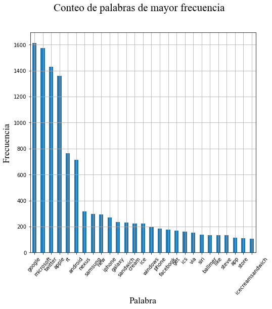

```python
csfont = {'fontname':'Times New Roman'}
plt.figure(figsize=(8,8))
freq[freq>v_i].sort_values(ascending=False).plot.bar().grid()
plt.xticks(rotation=50)
plt.xlabel("Palabra", fontsize=18,**csfont)
plt.ylabel("Frecuencia", fontsize=18,**csfont)
plt.suptitle('Conteo de palabras de mayor frecuencia', fontsize=21,**csfont)
plt.show()
```

Finalmente, podemos utilizar estas palabras como significativas para posteriormente filtrarlas como importantes para el análisis.

```python
print(list(dtm4))
```

```
['also', 'amazing', 'amazon', 'android', 'another', 'app', 'apple', 'apps', 'asia', 'asiaclassifiedtoday', 'available', 'awesome', 'baby', 'back', 'bad', 'ballmer', 'battery', 'beam', 'best', 'better', 'big', 'bing', 'bit', 'blackberry', 'blog', 'bookcase', 'buenas', 'business', 'buy', 'buying', 'ca…
```

## Quinta parte: Tiempos de ejecución

```python
x = [1000,2000,3000,4000,5113]
c1=[7887.25,16178.5,23584.2,29634.4,36156.7]
c2=[8588.89,17468.8,24841.2,31519.3,38856.8]
c3=[11346.9,22284.7,32778.9,40964.8,50889.7]
```

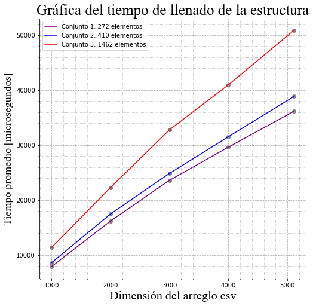

```python
csfont = {'fontname':'Times New Roman'}
fig = plt.figure(figsize=(8, 8))
plt.scatter(x, c1, color='gray')
plt.scatter(x, c2, color='gray')
plt.scatter(x, c3, color='gray')

plt.plot(x, c1, color='purple',label='Conjunto 1: 272 elementos')
plt.plot(x, c2, color='blue',label='Conjunto 2: 410 elementos')
plt.plot(x, c3, color='red',label='Conjunto 3: 1462 elementos')

plt.minorticks_on()
plt.grid(which='major', linestyle='--')
plt.grid(which='minor', linestyle=':')
plt.xlabel("Dimensión del arreglo csv",fontsize=20,**csfont)
plt.ylabel("Tiempo promedio [microsegundos]",fontsize=18,**csfont)
plt.title("Gráfica del tiempo de llenado de la estructura",fontsize=25,**csfont)
plt.legend(loc='best')
plt.show()
```

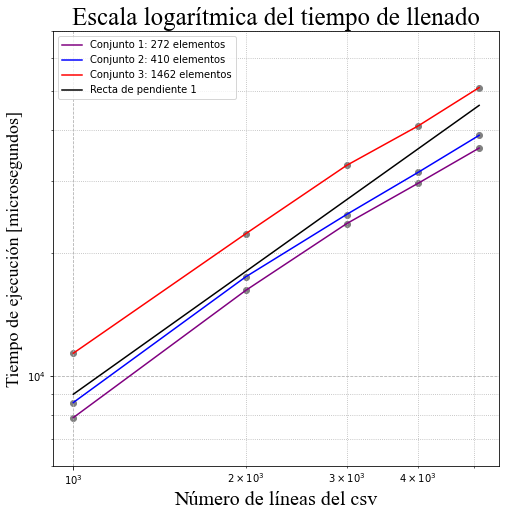

```python
n=1
x1=1000
x2=5113

y1=m.log10(10)*9000
y2=10**(n*(m.log10(x2)-m.log10(x1))+m.log10(y1))
xx = [x1,x2]
y = [y1,y2]

csfont = {'fontname':'Times New Roman'}
fig = plt.figure(figsize=(8, 8))
plt.scatter(x, c1, color='gray')
plt.scatter(x, c2, color='gray')
plt.scatter(x, c3, color='gray')

plt.plot(x, c1, color='purple',label='Conjunto 1: 272 elementos')
plt.plot(x, c2, color='blue',label='Conjunto 2: 410 elementos')
plt.plot(x, c3, color='red',label='Conjunto 3: 1462 elementos')
plt.plot(xx, y, color='black',label='Recta de pendiente 1')

plt.ylim([6000, 70000])
plt.grid(which='major', linestyle='--')
plt.grid(which='minor', linestyle=':')
plt.semilogx()
plt.semilogy()
plt.xlabel("Número de líneas del csv",fontsize=20,**csfont)
plt.ylabel("Tiempo de ejecución [microsegundos]",fontsize=18,**csfont)
plt.title("Escala logarítmica del tiempo de llenado",fontsize=25,**csfont)
plt.legend(loc='best')
plt.show()
```